# Insights into FordGoBike Data

## by Jing Lu

## Investigation Overview

> In this investigation, I looked at
> 1. Demographics of users
> 2. How trip duration varies across different groups of users (Subscriber vs Customer) ?
> 3. How user activity level varies across different groups of users (Subscriber vs Customer) ?
> 4. What are the most taken trips across different groups of users (Subscriber vs Customer) ?

## Dataset Overview

> The data, provided by Ford GoBike, a bike-sharing system, contains information of rides in the greater San Francisco Bay area. Each trip includes user info (type, gender, birth-year), time info (start time, end time, duration), location (start/end station id/name/longitude/longitude. The analysis is based on 2018's data. 110718 data points out of 1863721 are dropped due to missing information. Columns of 'start_station_latitude', 'start_station_longitude', 'end_station_latitude', 'end_station_longitude' and 'bike_share_for_all_trip' are dropped.

### Demographics of Ford GoBike's Users in the Greater San Francisco Bay Area

1. About 73.5% users are male, 25% are female, and 1.5% are other.
2. About 89% users are subscribers.
3. About 99% user <= 65 years old.

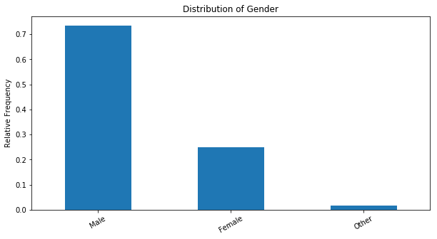

```python
# By gender
(df_2018.user_gender.value_counts()/len(df_2018)).plot(kind = 'bar', figsize = [10, 5], rot = 30, color = basecolor)
plt.ylabel('Relative Frequency')
plt.title('Distribution of Gender');
```

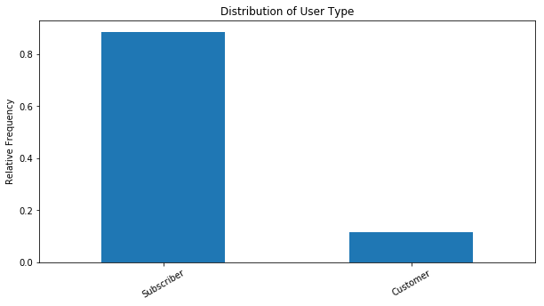

```python
# By type of user
(df_2018.user_type.value_counts()/len(df_2018)).plot(kind = 'bar', figsize = [10, 5], rot = 30, color = basecolor)
plt.ylabel('Relative Frequency')
plt.title('Distribution of User Type');
```

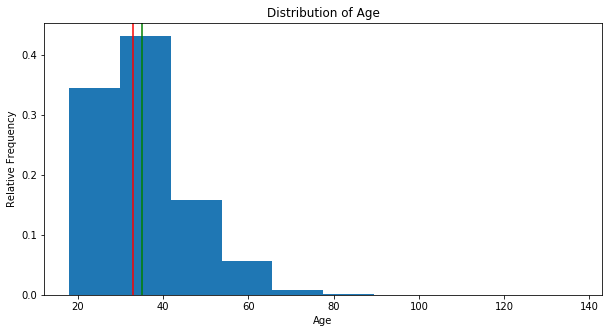

```python
# By age
age_min = (2018 - df_2018.user_birth_year).min()
age_max = (2018 - df_2018.user_birth_year).max()
age_mean =  (2018 - df_2018.user_birth_year).mean()
age_median =  (2018 - df_2018.user_birth_year).median()
xbins = np.arange(age_min, age_max + 10, 10)
(2018 - df_2018.user_birth_year).plot(kind = 'hist', weights = np.zeros_like(df_2018.user_birth_year) + 1/df_2018.user_birth_year.size, figsize = [10, 5], grid = False)
plt.xlabel('Age')
plt.ylabel('Relative Frequency')
plt.title('Distribution of Age')
plt.axvline(age_mean, color = 'g', label = 'mean')
plt.axvline(age_median, color = 'r', label = 'median')
```

### Distribution of Trip Duration

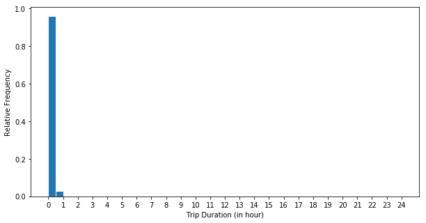

```python
xbins = np.arange(0, df_2018.duration_sec.max()/3600 + 0.5, 0.5)
xticks = np.arange(0, df_2018.duration_sec.max()/3600 + 1, 1)
((df_2018.duration_sec)/3600).hist(figsize = [10, 5], bins = xbins, weights = np.zeros_like(df_2018.duration_sec) + 1/df_2018.duration_sec.size, grid = False, edgecolor = 'white')
plt.xlabel('Trip Duration (in hour)')
plt.xticks(xticks)
plt.ylabel('Relative Frequency');
```

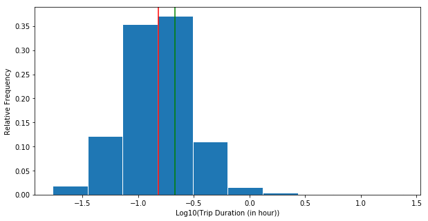

```python
(np.log10(df_2018.duration_sec/3600)).hist(figsize = [10, 5], weights = np.zeros_like(df_2018.duration_sec) + 1/df_2018.duration_sec.size, grid = False, edgecolor = 'white')
plt.axvline(np.log10(df_2018.duration_sec.mean()/3600), color = 'g', label = 'mean')
plt.axvline(np.log10(df_2018.duration_sec.median()/3600), color = 'r', label = 'median');
plt.xlabel('Log10(Trip Duration (in hour))')
plt.ylabel('Relative Frequency');
```

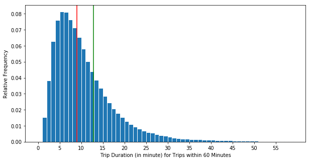

```python
# trips with duration within 60 minutes
xbins = np.arange(0, 60, 1)
xticks = np.arange(0, 60, 5)
((df_2018.duration_sec)/60).hist(figsize = [10, 5], bins = xbins, grid = False, density = True, edgecolor='white')
plt.xlabel('Trip Duration (in minute) for Trips within 60 Minutes')
plt.xticks(xticks)
plt.ylabel('Relative Frequency');
plt.axvline(df_2018.duration_sec.mean()/60, color = 'g', label = 'mean')
plt.axvline(df_2018.duration_sec.median()/60, color = 'r', label = 'median');
```

### Trip Duration vs User Type

The trip druation of the Customer group is longer than the Subsciber group while both follow the same pattern.

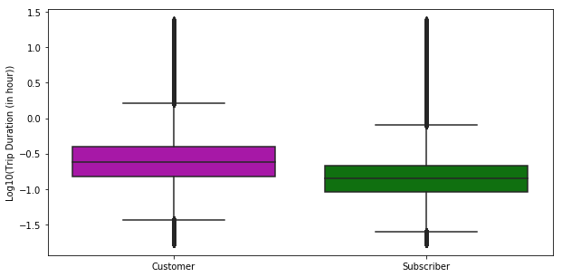

```python
# boxplot
plt.figure(figsize = [10, 5])
sb.boxplot(data = df_2018, x = 'user_type' , y = np.log10(df_2018.duration_sec/3600), palette = ["m", "g"])
plt.xlabel("")
plt.ylabel("Log10(Trip Duration (in hour))");
```

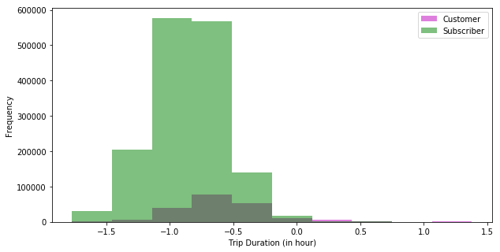

```python
# hist
plt.figure(figsize = [10, 5])
plt.hist(np.log10(df_2018[df_2018.user_type == 'Customer'].duration_sec/3600), alpha = 0.5, label = 'Customer', color = 'm')
plt.hist(np.log10(df_2018[df_2018.user_type == 'Subscriber'].duration_sec/3600), alpha = 0.5, label = 'Subscriber', color = 'g')
plt.ylabel('Frequency')
plt.xlabel('Trip Duration (in hour)')
plt.legend();
```

### User Activity Level over Time

1. Users are most active in 8:00 - 9:00, 17:00 - 18:00, followed by 9:00AM - 10:00AM, 18:00 - 19:00, and then 16:00 - 17:00 - those are rush hours.
2. Users are more active on weekdays than weekends.
3. Activities increase when weather gets warmer, reach and keep at a stable level during summer, climb to the peak around Oct, and then decrease as weather turns colder.

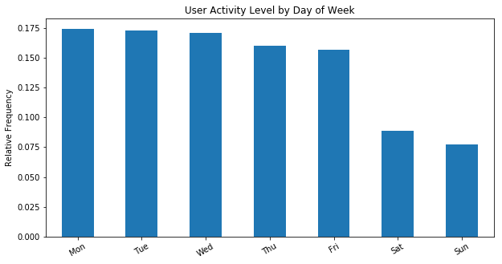

```python
(df_2018.start_time.dt.dayofweek.value_counts()/len(df_2018)).plot(kind = 'bar', figsize = [10, 5], rot = 30, color = basecolor)
locs, labels = plt.xticks()
labels = ['Mon', 'Tue', 'Wed', 'Thu', 'Fri', 'Sat', 'Sun']
plt.xticks(locs, labels)
plt.ylabel('Relative Frequency')
plt.title('User Activity Level by Day of Week');
```

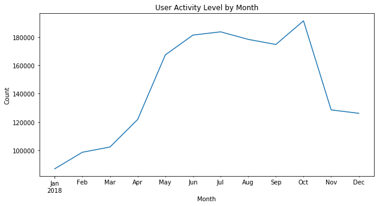

```python
df_2018.groupby(df_2018.start_time.dt.to_period('M')).agg('count')['bike_id'].plot(kind = 'line', figsize = [10, 5])
plt.xlabel('Month')
plt.ylabel('Count')
plt.title('User Activity Level by Month')
```

### User Activity Level over Time vs Type of User

1. The Subscriber group follows the pattern on the entire dataset tightly (in all three granularities: hour of day, day of week, month of year.
2. The Customer group kind of smoothes the overall user activity level, especially in the granularity of hour.
3. More interestingly, the Customer group is much more active than the Subscriber group over weekends and from 11:00 to 16:00. Plus, the activity of the Customer group trends up after 10:00 and reaches the peark at 17:00.

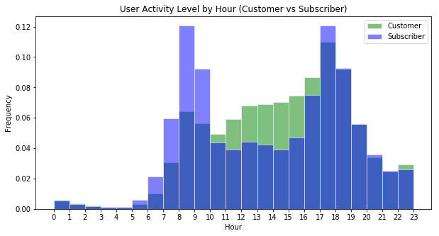

```python
bins = np.arange(0, 24, 1)
df_2018[df_2018.user_type == 'Customer'].start_time.dt.hour.plot(kind = 'hist', alpha = 0.5, weights = np.zeros_like(df_2018[df_2018.user_type == 'Customer'].duration_sec) + 1/(df_2018.user_type == 'Customer').sum(), figsize = [10, 5], bins = bins, grid = False, edgecolor = 'white', color = 'g', label = 'Customer')
df_2018[df_2018.user_type == 'Subscriber'].start_time.dt.hour.plot(kind = 'hist', alpha = 0.5, weights = np.zeros_like(df_2018[df_2018.user_type == 'Subscriber'].duration_sec) + 1/(df_2018.user_type == 'Subscriber').sum(), figsize = [10, 5], bins = bins, grid = False, edgecolor = 'white', color = 'b', label = 'Subscriber')
plt.xlabel('Hour')
plt.xticks(bins);
plt.ylabel('Frequency')
plt.title('User Activity Level by Hour (Customer vs Subscriber)');
plt.legend()
```

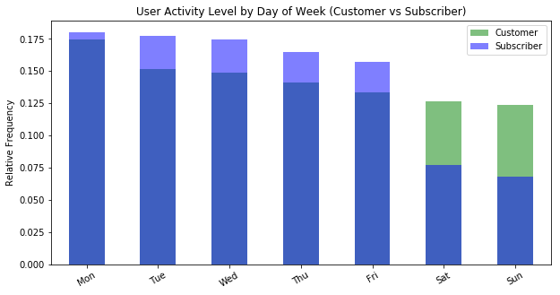

```python
(df_2018[df_2018.user_type == 'Customer'].start_time.dt.dayofweek.value_counts()/(df_2018.user_type == 'Customer').sum()).plot(kind = 'bar', alpha = 0.5, figsize = [10, 5], rot = 30, label = 'Customer', color = 'g')
(df_2018[df_2018.user_type == 'Subscriber'].start_time.dt.dayofweek.value_counts()/(df_2018.user_type == 'Subscriber').sum()).plot(kind = 'bar', alpha = 0.5, figsize = [10, 5], rot = 30, label = 'Subscriber', color = 'b')
locs, labels = plt.xticks()
labels = ['Mon', 'Tue', 'Wed', 'Thu', 'Fri', 'Sat', 'Sun']
plt.xticks(locs, labels)
plt.ylabel('Relative Frequency')
plt.title('User Activity Level by Day of Week (Customer vs Subscriber)');
plt.legend()
```

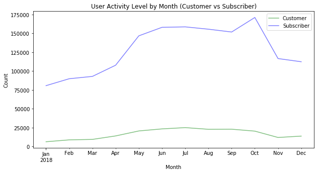

```python
df_2018[df_2018.user_type == 'Customer'].groupby(df_2018[df_2018.user_type == 'Customer'].start_time.dt.to_period('M')).agg('count')['bike_id'].plot(kind = 'line', alpha = 0.5, color = 'g', label = 'Customer', figsize = [10, 5])
df_2018[df_2018.user_type == 'Subscriber'].groupby(df_2018[df_2018.user_type == 'Subscriber'].start_time.dt.to_period('M')).agg('count')['bike_id'].plot(kind = 'line', alpha = 0.5, color = 'b', label = 'Subscriber', figsize = [10, 5])
plt.xlabel('Month')
plt.ylabel('Count')
plt.title('User Activity Level by Month (Customer vs Subscriber)')
plt.legend()
```

### What Trips are Most Taken ?

How to define a trip? By start station? By end station? Or by pair of start staion and end station?

1. By 'pair of start_station and end_station': the top 20 trips only count for 3.55% of total trips.
2. By 'start station': top 20 trips count for 28.05% of total trips.
3. By 'end station: top 20 trips count for 30.27% of total trips.
4. 'Top 20 trips by start station' and 'Top 20 trips by end station' have a large degree of overlap : 19 out of 20

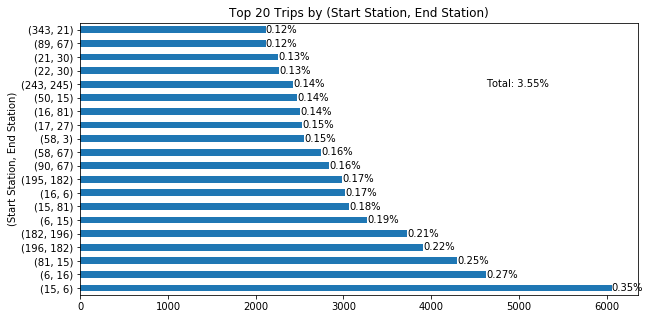

```python
toptrips_by_start_end = df_2018.groupby(['start_station_id', 'end_station_id']).count().bike_id.sort_values(ascending = False).nlargest(20)
toptrips_by_start_end.plot(kind = 'barh', figsize = [10, 5], color = basecolor)
plt.ylabel('(Start Station, End Station)')
plt.title('Top 20 Trips by (Start Station, End Station)');
toptrips_by_start_end = toptrips_by_start_end.reset_index()
for i in range(len(toptrips_by_start_end)):
    text = "{:.2%}".format(toptrips_by_start_end.loc[i, 'bike_id']/len(df_2018))
    plt.text(toptrips_by_start_end.loc[i, 'bike_id'] + 1, i, text, va = 'center')
plt.text(toptrips_by_start_end.loc[1, 'bike_id'] + 1, 15, "Total: " + "{:.2%}".format(toptrips_by_start_end.bike_id.sum()/len(df_2018)), va = 'center');
```

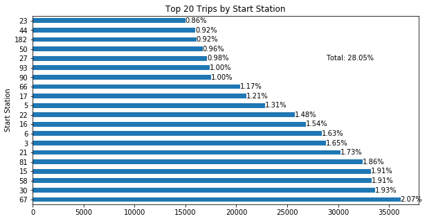

```python
toptrips_by_start = df_2018.groupby(['start_station_id']).count().bike_id.sort_values(ascending = False).nlargest(20)
toptrips_by_start.plot(kind = 'barh', figsize = [10, 5], color = basecolor)
toptrips_by_start = toptrips_by_start.reset_index()
plt.ylabel('Start Station')
plt.title('Top 20 Trips by Start Station');
for i in range(len(toptrips_by_start)):
    text = "{:.2%}".format(toptrips_by_start.loc[i, 'bike_id']/len(df_2018))
    plt.text(toptrips_by_start.loc[i, 'bike_id'] + 1, i, text, va = 'center')
plt.text(toptrips_by_start.loc[6, 'bike_id'] + 1, 15, "Total: " + "{:.2%}".format(toptrips_by_start.bike_id.sum()/len(df_2018)), va = 'center');
```

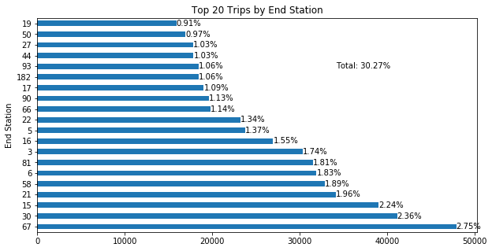

```python
toptrips_by_end = df_2018.groupby(['end_station_id']).count().bike_id.sort_values(ascending = True).nlargest(20)
toptrips_by_end.plot(kind = 'barh', figsize = [10, 5], color = basecolor)
toptrips_by_end = toptrips_by_end.reset_index()
plt.ylabel('End Station')
plt.title('Top 20 Trips by End Station');
for i in range(len(toptrips_by_end)):
    text = "{:.2%}".format(toptrips_by_end.loc[i, 'bike_id']/len(df_2018))
    plt.text(toptrips_by_end.loc[i, 'bike_id'] + 1, i, text, va = 'center')
plt.text(toptrips_by_end.loc[3, 'bike_id'] + 1, 15, "Total: " + "{:.2%}".format(toptrips_by_end.bike_id.sum()/len(df_2018)), va = 'center');
```

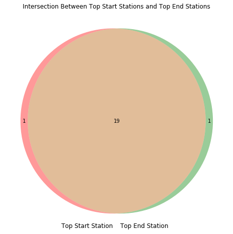

```python
topstart_set = set(toptrips_by_start.start_station_id.tolist())
topend_set = set(toptrips_by_end.end_station_id.tolist())
topcommonstation_set = topstart_set & topend_set
from matplotlib_venn import venn2, venn2_circles
plt.figure(figsize = (12, 8))
venn2([topstart_set, topend_set], set_labels = ('Top Start Station', 'Top End Station'))
plt.title('Intersection Between Top Start Stations and Top End Stations');
```

### Top Trips by Type of User

1. The Subscriber group has greater overlap between top start stations and top end stations than the Customer group (19 versus 17) - it follows the pattern on the entire dataset more closely.

```python
# start station
start_usertype_count = df_2018.groupby(['user_type', 'start_station_id']).count().bike_id.sort_values(ascending = False)
start_usertype_count = start_usertype_count.reset_index()
start_usertype_count.rename(index = str, columns = {"bike_id" : "count"}, inplace = True)
# top start stations for customer
topstart_customer_set = set(start_usertype_count[start_usertype_count.user_type == 'Customer'].sort_values(by = 'count', ascending = False).nlargest(columns = 'count', n = 20).start_station_id.tolist())
# top start stations for subscriber
topstart_subscriber_set = set(start_usertype_count[start_usertype_count.user_type == 'Subscriber'].sort_values(by = 'count', ascending = False).nlargest(columns = 'count', n = 20).start_station_id.tolist())

# end Station
end_usertype_count = df_2018.groupby(['user_type', 'end_station_id']).count().bike_id.sort_values(ascending = False)
end_usertype_count = end_usertype_count.reset_index()
end_usertype_count.rename(index = str, columns = {"bike_id" : "count"}, inplace = True)
# top end stations for customer
topend_customer_set = set(end_usertype_count[end_usertype_count.user_type == 'Customer'].sort_values(by = 'count', ascending = False).nlargest(columns = 'count', n = 20).end_station_id.tolist())
# top end stations for subscriber
topend_subscriber_set = set(end_usertype_count[end_usertype_count.user_type == 'Subscriber'].sort_values(by = 'count', ascending = False).nlargest(columns = 'count', n = 20).end_station_id.tolist())
```

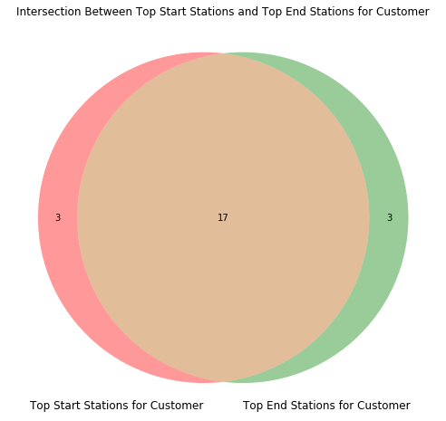

```python
# Intersection between top start stations and top end stations for customer
plt.figure(figsize = (12, 8))
venn2([topstart_customer_set, topend_customer_set], set_labels = ('Top Start Stations for Customer', 'Top End Stations for Customer'));
plt.title('Intersection Between Top Start Stations and Top End Stations for Customer');
```

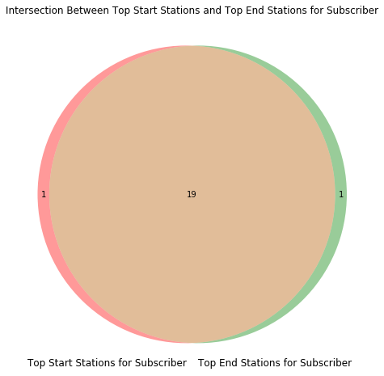

```python
# intersection between top start stations and top end stations for subscriber
plt.figure(figsize = (12, 8))
venn2([topstart_subscriber_set, topend_subscriber_set], set_labels = ('Top Start Stations for Subscriber', 'Top End Stations for Subscriber'));
plt.title('Intersection Between Top Start Stations and Top End Stations for Subscriber');
```